# Single-step Hybrid Predition

Matthias Westhues, Claas Heuer

2017-02-09

# Preface

This report covers an extension of the methodology of single-step prediction — which was developed for the imputation of SNP data from pedigree information — to the imputation of quantitative predictor variables using genomic information.

Here, we are working with a “full” data set — referring to the maximum number of hybrids for which agronomic and genomic, but not necessarily transcriptomic data are available — and a “reduced” data set with less hybrids but all of their parental inbred lines having complete genomic and transcriptomic records.

All our predictive abilities were evaluated using a leave-one-out cross validation (LOOCV) routine and results are displayed for T0-hybrids only. Note, that T0-hybrids are defined as hybrids having zero parents that have been previously tested in other hybrid combinations.

The companion R-package for this analysis is sspredr. The development version can be installed from Github:

```r
devtools::install_github("mwesthues/sspredr")
```

## 0.1 Objectives

1. Assess whether transcriptomic data with missing records for some genotypes can be imputed successfully based on genomic information to improve prediction of unseen hybrids.
2. Explore the utility of various machine learning algorithms for the prediction of unseen hybrids.[^1]

## 0.2 Overview

Chapter 1 gives a summary of the relevant literature.

Chapter 2 provides a brief summary of the available data without delving into their properties.

Chapter 3 gives an overview of the distribution of the agronomic traits as well as correlations among them, separately for the full set of hybrids as well as the reduced set of hybrids.

Chapter 4 explores the distribution and correlations of/among transcriptomic predictors for “raw” and transformed mRNA BLUEs.

Chapter 5 examines the correlation between the original and imputed transcriptomic BLUEs.

Chapter 6 introduces the different predictor sets that were used for predictions.

Chapter 7 gives the distribution of coefficients in the different kernel matrices used in hybrid prediction.

Chapter 8 gives the distribution of coefficients in $\mathbf{W}$ after applying centering, scaling, transformations and feature filtering on the original matrices.

Chapter 9 deals with the results of hybrid prediction for the reduced set of data and a comparison of predictive abilities with the full data set.

# 1 Introduction

The integration of different sources of information for the prediction of breeding or production values is one of the major challenges in current genomic prediction research. In the early years of genomic prediction, a 2-step procedure was the most intuitive choice for establishing a new selection scheme. The first consists of conventionally estimating breeding values based on pedigree relationships and therefore the phenotypes of relatives. Individuals with accurate breeding values out of the first step (i.e. high number of offspring), enter the second step in which SNP genotypes are regressed against the conventional breeding values. Those markers can then be used to predict genomic breeding values for solely genotyped and potentially very young individuals. Considering the two sources of information — pedigree and high density SNP genotypes — the process can be described as follows:

### 1.0.1 First Step

Denote $\mathbf{y}$ as the vector of measured phenotypes for a normally distributed trait for all individuals available in the population. The relationship — and therefore the strucure of the additive genetic covariance — across individuals is based on the numerator relationship matrix $\mathbf{A}$. In order to obtain breeding values for any individual in the population, we consider the following model:

$$\begin{equation}
\tag{1.1}
\mathbf{y} = \mathbf{Xb} + \mathbf{Za} + \mathbf{e},
\end{equation}$$

where $\mathbf{X}$ is a design matrix for fixed effects, $\mathbf{b}$ is a vector of fixed effects, $\mathbf{Z}$ is the design matrix for the random animal effects, which associate observations in $\mathbf{y}$ with elements in $\mathbf{A}$, $\mathbf{a}$ is the vector of random animal effects (=breeding values) and $\mathbf{e}$ is a vector of iid residual errors with expectation $0$ and variance $\sigma^2_e$. The distribution of the random vector $\mathbf{a}$ is $MVN(0, \mathbf{A}\sigma^2_a)$.

### 1.0.2 Second Step

In the second step, a subset of the individuals for which conventional breeding values have been estimated, is selected and enters the reference population for training a genomic prediction model. That selection requires that the individual is genotyped and has $\text{PEV}(a_{\text{candidate}}) \leq \text{threshold}$. As the breeding values from step one enter the genomic prediction model as phenotypes, one has to be careful about the residual error distribution of such a model. For instance, if the range of the prediction error variances is very broad in the reference population, the residual errors will not be identically distributed anymore, e.g. they should be weighted differently or estimated individually. One popular approach to account for that problem is *Deregressing* the breeding values and weighting the residuals according to the prediction error variances (Garrick, Taylor, and Fernando 2009). Genomic breeding values for any animal in the population can then be obtained by:

$$\begin{equation}
\tag{1.2}
\mathbf{\tilde{g}} = (\mathbf{M} - 2\mathbf{p})\mathbf{\hat{u}},
\end{equation}$$

where $\mathbf{p}$ is a row-vector of allele frequencies in the base population, $\mathbf{M}$ is a matrix of marker covariates and $\mathbf{u}$ is a vector of marker effects. The prediction error variance of the vector $\mathbf{\tilde{g}}$ is usually globally obtained using cross validation. Alternatively they could be obtained individually by the posterior distribution of $(\mathbf{M} - 2\mathbf{p})\mathbf{\hat{u}}$ when a Bayesian model is used.

## 1.1 Single Step Transciptomic prediction of Breeding Values

The breeding values in a mRNA prediction model are in general given by:
$$\begin{equation}
\tag{1.3}
\mathbf{\tilde{g}} = \mathbf{W}\boldsymbol{\hat{\alpha}},
\end{equation}$$

where $\boldsymbol{\hat{\alpha}}$ is the solution to a ridge regression model equaivalent to the GBLUP model but using mRNA covariates ($\mathbf{W}$) instead of marker genotypes.

Consider now the situation in which only a subset of the population has transcriptomic information but all have SNP genotypes. We can take a similar route as in Fernando, Dekkers, and Garrick (2014) and impute missing mRNA data. The difference here is that — instead of predicting SNP covariates using pedigree relationship — we impute mRNA covariates using SNP or genomic relationships. Let the subscript $1$ denote individuals for which SNP genotypes but no mRNA data are available. Individuals with subscript $2$ have both, SNP and mRNA information. The covariates in $\mathbf{W}$ are centered. The vector $\mathbf{g}_1$ can be written as the sum of the conditional expectation given $\mathbf{g}_2$ and a residual error term:
$$\begin{align}
\tag{1.4}
\mathbf{g_1} &= E(\mathbf{g}_1|\mathbf{g}_2) + \boldsymbol{\epsilon} \\
&= \mathbf{G_{12}}\mathbf{G_{22}}^{-1}\mathbf{W_2}\boldsymbol{\hat{\alpha}} + (\mathbf{g_1} - \mathbf{G_{12}}\mathbf{G_{22}}^{-1}\mathbf{W_2}\boldsymbol{\hat{\alpha}}) \\
&= \mathbf{\hat{g}}_1 + \boldsymbol{\epsilon}
\end{align}$$

The covariance matrix of $\boldsymbol{\epsilon}$ is $\mathbf{G}_{11} - \mathbf{G}_{12}\mathbf{G}_{22}^{-1}\mathbf{G}_{21} = (\mathbf{G}^{11})^{-1}$ (Legarra, Aguilar, and Misztal 2009).

The structure of the residual imputation/prediction error is known and can therefore be modelled. The missing mRNA covariates can be predicted using the expectation of a multivariate normal random vector given correlated observations, which are related to the Best Linear Predictor.

### 1.1.1 Extending the single step model

To this point, we have only taken the general idea behind single step genomic prediction and applied it to the situation in which the breeding values are defined as the sum of mRNA effects plus an *imputation error* term from using genomic relationships to impute missing mRNA data. It might also be interesting to include individuals which have neither mRNA nor SNP data available, but phenotypes. The general mRNA model for that situation could be written as:

$$\begin{equation}
\tag{1.5}
\mathbf{y} = \mathbf{Xb} + \mathbf{W} \boldsymbol{\alpha} + \mathbf{U}_{Ped} \boldsymbol{\epsilon}_{Ped}
+ \mathbf{U}_{SNP} \boldsymbol{\epsilon}_{SNP}+ \mathbf{e},
\end{equation}$$

with

$$\begin{equation}
\tag{1.6}
\mathbf{X} =
\begin{bmatrix}
X_0 \\
X_1 \\
X_2
\end{bmatrix},
\mathbf{W} =
\begin{bmatrix}
Z_0\hat{\mathbf{W}_0} \\
Z_1\hat{\mathbf{W}_1} \\
\mathbf{W}_2
\end{bmatrix},
\mathbf{U}_{Ped} =
\begin{bmatrix}
Z_0 \\
0 \\
0
\end{bmatrix},
\mathbf{U}_{SNP} =
\begin{bmatrix}
0 \\
Z_1 \\
0
\end{bmatrix},
\end{equation}$$

The subscript 0 denotes animals with Pedigree information and neither SNP nor mRNA data, 1 individuals with SNP but no mRNA data and 2 individuals with mRNA data.

Following the notation in Fernando, Dekkers, and Garrick (2014) the phenotypes can be untangled like this:

$$\begin{align}
\tag{1.7}
\begin{bmatrix}
y_0 \\
y_1 \\
y_2
\end{bmatrix}
& =
\begin{bmatrix}
X_0 \\
X_1 \\
X_2
\end{bmatrix}
\boldsymbol{\beta} +
\begin{bmatrix}
Z_0 & 0 & 0 \\
0 & Z_1 & 0 \\
0 & 0 & Z_2
\end{bmatrix}
\begin{bmatrix}
g_0 \\
g_1 \\
g_2
\end{bmatrix}
+ \mathbf{e} \\
& =
\begin{bmatrix}
X_0 \\
X_1 \\
X_2
\end{bmatrix}
\boldsymbol{\beta} +
\begin{bmatrix}
Z_0 & 0 & 0 \\
0 & Z_1 & 0 \\
0 & 0 & Z_2
\end{bmatrix}
\begin{bmatrix}
\mathbf{A}_{02}\mathbf{A}_{22}^{-1}\mathbf{W}_2\boldsymbol{\alpha} + \boldsymbol{\epsilon}_{Ped} \\
\mathbf{G}_{12}\mathbf{G}_{22}^{-1}\mathbf{W}_2\boldsymbol{\alpha} + \boldsymbol{\epsilon}_{SNP} \\
\mathbf{W}_2\boldsymbol{\alpha} \\
\end{bmatrix}
+ \mathbf{e} \\
& =
\begin{bmatrix}
X_0 \\
X_1 \\
X_2
\end{bmatrix}
\boldsymbol{\beta} +
\begin{bmatrix}
Z_0 & 0 & 0 \\
0 & Z_1 & 0 \\
0 & 0 & Z_2
\end{bmatrix}
\begin{bmatrix}
\hat{\mathbf{W}_0}\boldsymbol{\alpha} + \boldsymbol{\epsilon}_{Ped} \\
\hat{\mathbf{W}_1}\boldsymbol{\alpha} + \boldsymbol{\epsilon}_{SNP} \\
\mathbf{W}_2\boldsymbol{\alpha} \\
\end{bmatrix}
+ \mathbf{e} \\
\end{align}$$

The breeding values from that model are:

$$\begin{equation}
\tag{1.8}
\tilde{\mathbf{g}} =
\begin{bmatrix}
\hat{\mathbf{W}_0} \\
\hat{\mathbf{W}_1} \\
\mathbf{W}_2
\end{bmatrix}
\hat{\boldsymbol{\alpha}}
+
\begin{bmatrix}
\mathbf{Z}_0 \\
0 \\
0
\end{bmatrix}
\hat{\boldsymbol{\epsilon}}_{Ped}
+
\begin{bmatrix}
0 \\
\mathbf{Z}_1 \\
0
\end{bmatrix}
\hat{\boldsymbol{\epsilon}}_{SNP}
\end{equation}$$

When dealing with hybrid performance as phenotypes, we are interested in estimating general combining abilitiy (GCA) for every line of a specific subpopulation. In our case, the subpopulations comprise *dent* and *flint*. Hence, our final model looks like this:

$$\begin{align}
\tag{1.9}
\mathbf{y} &= \mathbf{Xb} \\
&+ \mathbf{Z}_{dent}\mathbf{W}_{dent} \boldsymbol{\alpha}_{dent} + \mathbf{Z}_{dent}\mathbf{U}_{dent_{Ped}} \boldsymbol{\epsilon}_{dent_{Ped}}
+ \mathbf{Z}_{dent}\mathbf{U}_{dent_{SNP}} \boldsymbol{\epsilon}_{dent_{SNP}} \\
&+ \mathbf{Z}_{flint}\mathbf{W}_{flint} \boldsymbol{\alpha}_{flint} + \mathbf{Z}_{flint}\mathbf{U}_{flint_{Ped}} \boldsymbol{\epsilon}_{flint_{Ped}}
+ \mathbf{Z}_{flint}\mathbf{U}_{flint_{SNP}} \boldsymbol{\epsilon}_{flint_{SNP}} \\
&+ \mathbf{e},
\end{align}$$

where $\mathbf{Z}_{dent}$ and $\mathbf{Z}_{flint}$ are design matrices that map hybrids to their respective parents in the dent and flint lines. The obtained GCA effects for the inbred lines represent half their breeding values. The predicted hybrid performance is:

$$\begin{equation}
\tag{1.10}
\tilde{\mathbf{h}} = \mathbf{Z}_{dent}\tilde{\mathbf{g}}_{dent} + \mathbf{Z}_{flint}\tilde{\mathbf{g}}_{flint}
\end{equation}$$

# 2 Data Overview

Agronomic data for 7 traits (including dry-matter yield (DMY)) and 1,521 hybrids are available (Table 2.1). After applying a series of quality checks, 21,953 SNPs and best linear unbiased estimates of 1,323 were available for further analyses. Genomic, pedigree and transcriptomic records, were collected for inbred parent lines of 685 hybrids.

Table 2.1: Number of genotypes for Dent and Flint parent lines and their hybrid progeny for which genomic and/or transcriptomic data are available. All genotypes for which transcriptomic data are available, also have genomic data. Agronomic data are available for all 1,521 hybrid genotypes.

| Pool | Data Type | n |
| --- | --- | --- |
| Dent | Agronomic | 142 |
| Dent | Transcriptomic | 60 |
| Dent | Pedigree | 142 |
| Dent | Genomic | 142 |
| Flint | Agronomic | 103 |
| Flint | Transcriptomic | 43 |
| Flint | Pedigree | 103 |
| Flint | Genomic | 103 |
| Hybrid | Agronomic | 1521 |
| Hybrid | Transcriptomic | 685 |

# 3 Agronomic Data

## 3.1 Skewness

A general rule of thumb to consider is that skewed data whose ratio of the highest value to the lowest value is greater than 20 have significant skewness. The formula for the skewness statistic is
$$\text{skewness} = \frac{\sum (x_i - \bar{x})^{3}}{(n - 1)v^{3/2}},$$
where $v = \frac{\sum (x_i - \bar{x})^2}{(n - 1)}$ with $x$ denoting the predictor variable, $n$ denoting the number of values and $\bar{x}$ denoting the sample mean of the predictor.

Table 3.1: Skewness of seven agronomic traits for the full set of hybrids and the reduced set of hybrids, respectively.

| Trait | Skewness (Full) | Skewness (Reduced) |
| --- | --- | --- |
| DMY | 0.19 | 0.28 |
| DMC | 0.47 | -0.08 |
| ADF | 0.29 | 0.58 |
| FAT | -0.21 | -0.35 |
| PRO | -0.04 | -0.01 |
| STA | -0.27 | -0.16 |
| SUG | 0.48 | 0.38 |

## 3.2 Distribution

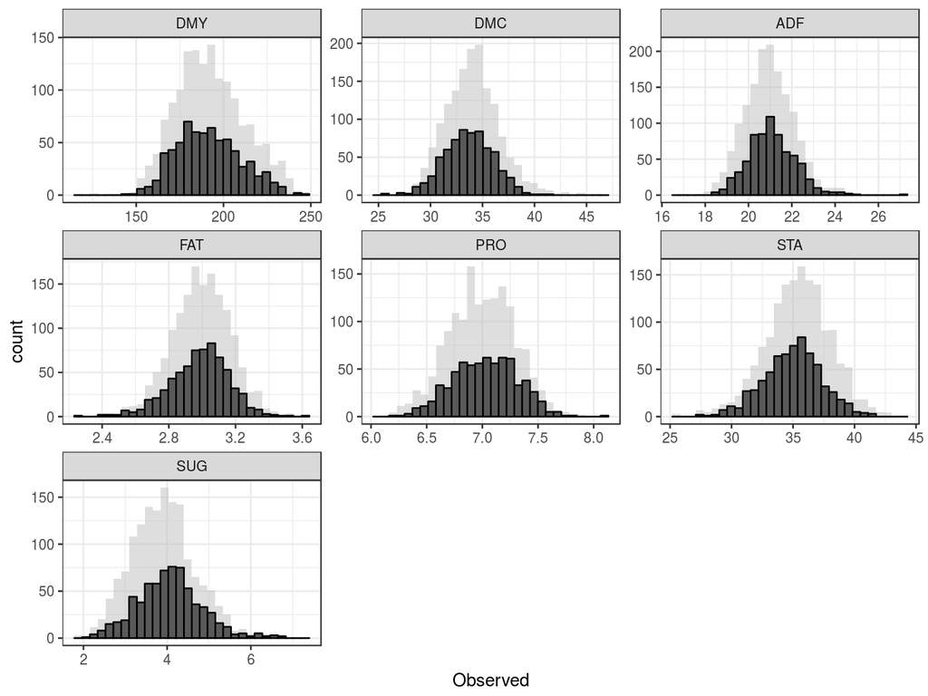

Figure 3.1: Histogram of the distribution of seven agronomic traits. Black bins show the distribution of the reduced set of hybrids whereas light grey bins show the distribution of the full set of hybrids.

## 3.3 Correlation

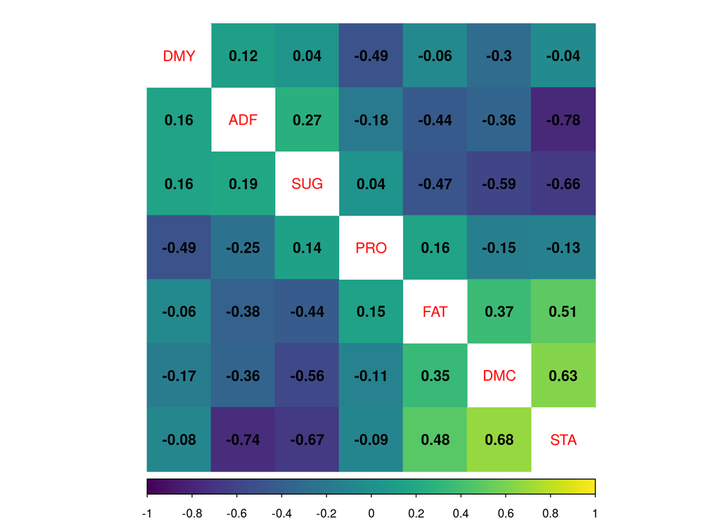

Figure 3.2: Pairwise correlations among seven agronomic traits for the full set of hybrids (upper diagonal) and the reduced set of hybrids (lower diagonal), respectively.

# 4 Transcriptomic Data

Keep only genotypes for which both, transcriptomic and genomic data are available.

Separately for each heterotic group, run a principal component analysis (PCA) on the “raw” mRNA-BLUEs and return the importance of the first three PCs.

## 4.1 Data pre-processing

Pre-process the data in the following order:

1. Near-zero-variance filtering.
2. Box-Cox tranformation
3. Centering
4. Scaling

Table 4.1: Importance of the first three PCs (in %)

| Type | Dent | Flint |
| --- | --- | --- |
| Raw | 24.36 | 25.56 |
| Trans | 21.99 | 23.24 |

## 4.2 Skewness

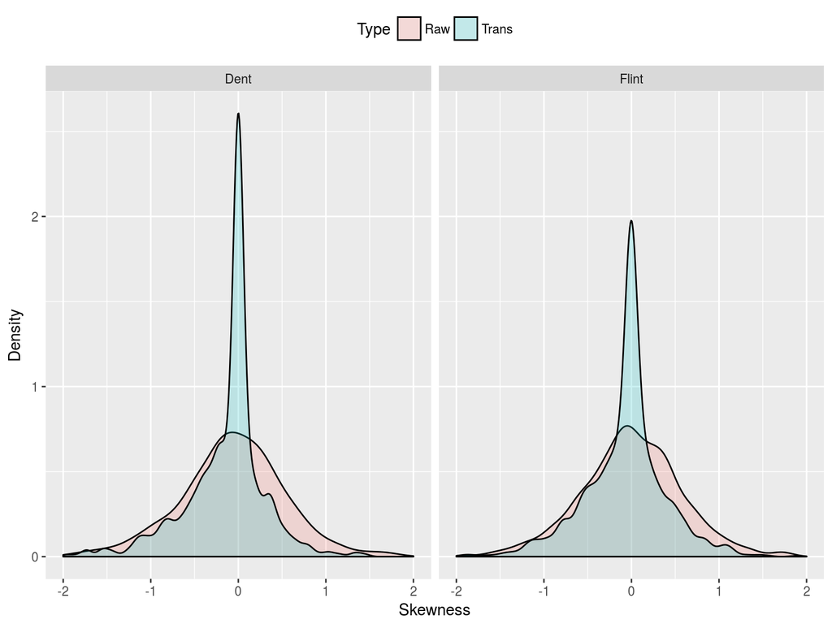

Figure 4.1: Distribution of skewness values across all mRNAs, separately for transformed and raw BLUEs.

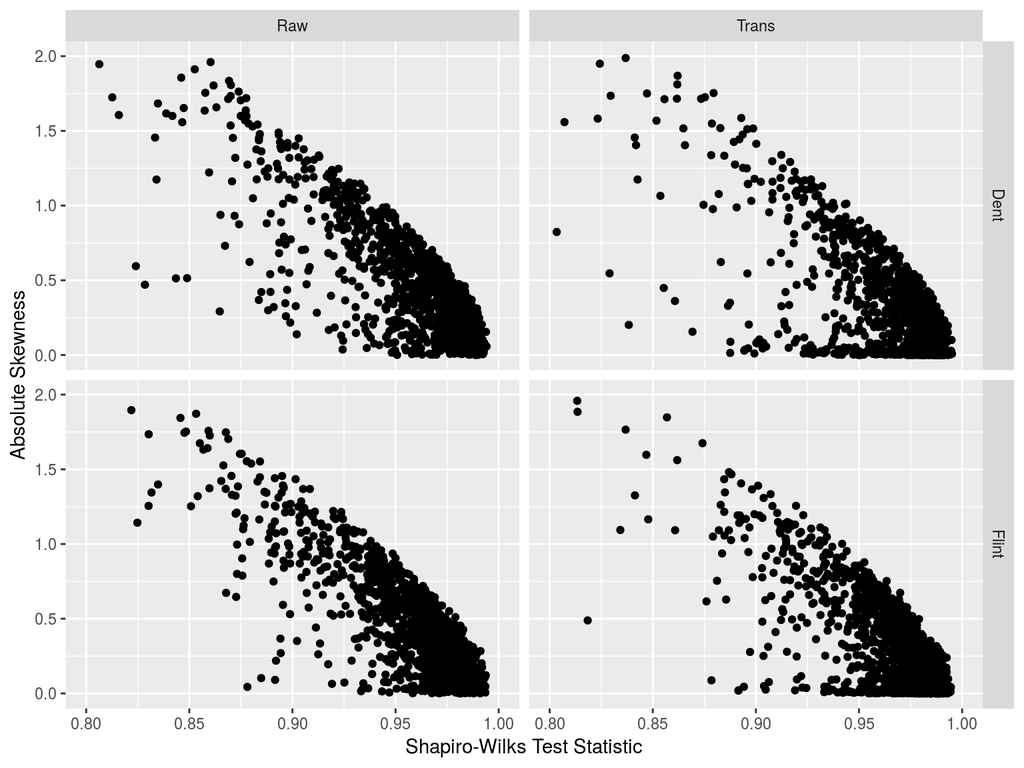

Figure 4.2: Shapiro-Wilks Test Statistic vs absolute skewness for transcriptomic BLUEs depending on whether the BLUEs were transformed or not.

# 5 Genotype-Wise mRNA-Imputation

## 5.1 Correlations between vectors of original and imputed mRNAs.

### 5.1.1 General idea:

- Impute transcriptomic data for different numbers of genotypes (from 1 to number of genotypes with transcriptomic data).
- For each number of genotypes without transcriptomic data, randomly sample 1000 sets of genotypes, which will be imputed. This will allow us to aggregate and summarize the correlation between observed and imputed mRNAs with high confidence.

The computations were run using multiple cores with this script.

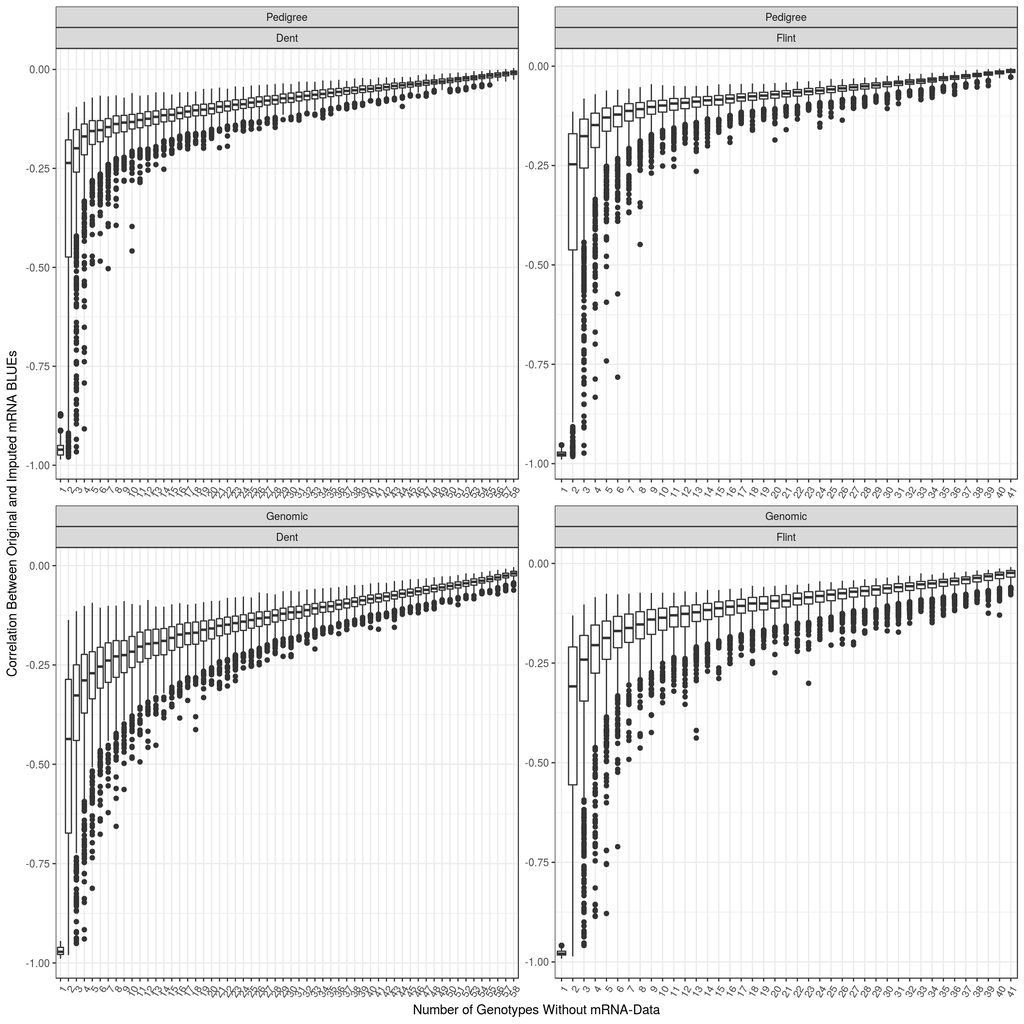

Figure 5.1: Pearson correlation coefficients between original and imputed mRNA genotypes for two heterotic groups and two sources of information (i.e. genomic and pedigree), depending on the number of genotypes without mRNA records. Genotypes without mRNA records were declared as such at random.

# 6 Predictor Subsetting

Goal: Generate nine subsets of predictors for later comparisons between their predictive abilities:

1. 100% SNP (`snp100`)
2. 100% pedigree (`ped100`)
3. 42% mRNA (`mrna42`)
4. 42% pedigree (`ped42`)
5. 42% SNP (`snp42`)
6. 100% pedigree & 77% SNP (`ped100_snp77`)
7. 100% pedigree & 42% mRNA (`ped100_mrna42`)
8. 100% SNP & 42% mRNA (`snp100_mrna42`)
9. 100% pedigree & 77% SNP & 42% mRNA (`ped100_snp77_mrna42`)

Make comparisons between the following scenarios:

1. a, b, f, g, h, i
2. c, d, e

Throughout this manuscript, digits behind the variable name of each predictor (ped: pedigree, snp: genomic, mrna: transcriptomic) indicate the size of the subset relative to the full set of genotypes (n = 245). For example, we have transcriptomic data for 103 genotypes, which are roughly 42% of 245 genotypes, hence the name ‘mrna42’ and so forth. For the set “snp77”, all genotypes — for which transcriptomic records are available — were used and the remaining genotypes were sampled at random with equally large proportions being sampled from the Dent and the Flint heterotic group, respectively.

# 7 Original Kernels

With the original configuration of the predictors, very low predictive abilities were obtained for the amalgamation of pedigree, genomic and transcriptomic information, regardless of the phenotypic trait. One of the possible causes were inconsistencies in the functions `impute_eta()` and `impute2` from the `sspredr` package regarding the factorization of matrices. After tackling those bugs, we wanted to revisit the distribution of the coefficients from the matrix $\mathbf{W}$ in (1.5).

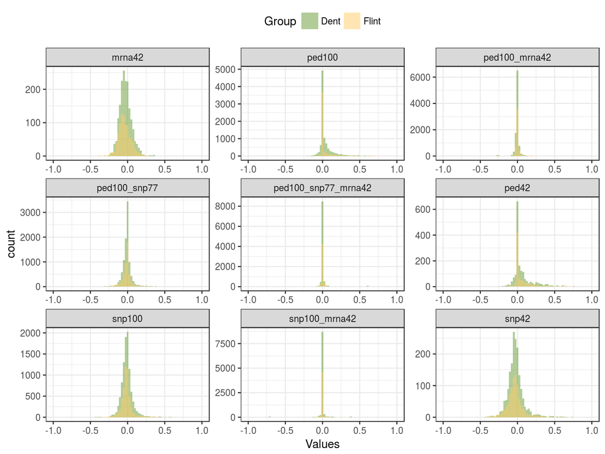

Figure 7.1: Distribution of coefficients that are elements of the unmodified kernel matrices ($\mathbf{W}$) used in single step or regular prediction of hybrid performance.

# 8 Transformed Kernels

After noticing extremely narrow distributions in the coefficients of $\mathbf{W}$ (defined in Eq. (1.5), Fig. 7.1), we decided to explore the effect of several data pre-processing procedures on the distribution of the coefficients. Separately for each heterotic group, the following data pre-processing procedures were applied to the transcriptomic data: i) Box-Cox transformation, ii) centering, iii) scaling, removal of features with a correlation $\rho \geq 0.999$, using the function `preProcess` from the R package `caret` (Kuhn and Johnson 2013). Separately for each heterotic group and each subset of features (i.e. `snp100`, `snp77` and `snp42`), only SNPs that were not in perfect linkage disequilibrium with another marker were kept. From Fig. 8.1 we can glean that data processing had a considerable, positive effect on the distribution of coefficients in $\mathbf{W}$, which became wider in the case of predictor combinations such as `ped100_snp77_mrna42` compared to unprocessed features (Fig 7.1).

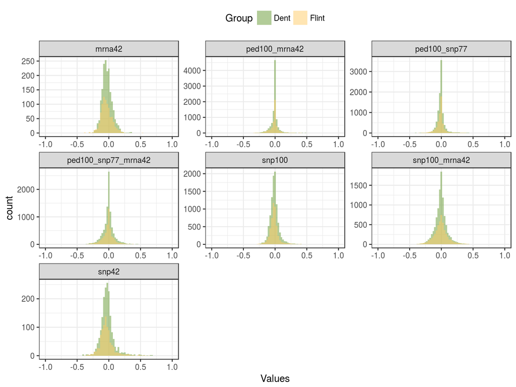

Figure 8.1: Distribution of coefficients that are elements of the transformed kernel matrices $\mathbf{W}$ used in single step or regular prediction of hybrid performance.

# 9 LOOCV-Transformed-Kernel-Prediction

## 9.1 Distribution of predicted and observed values

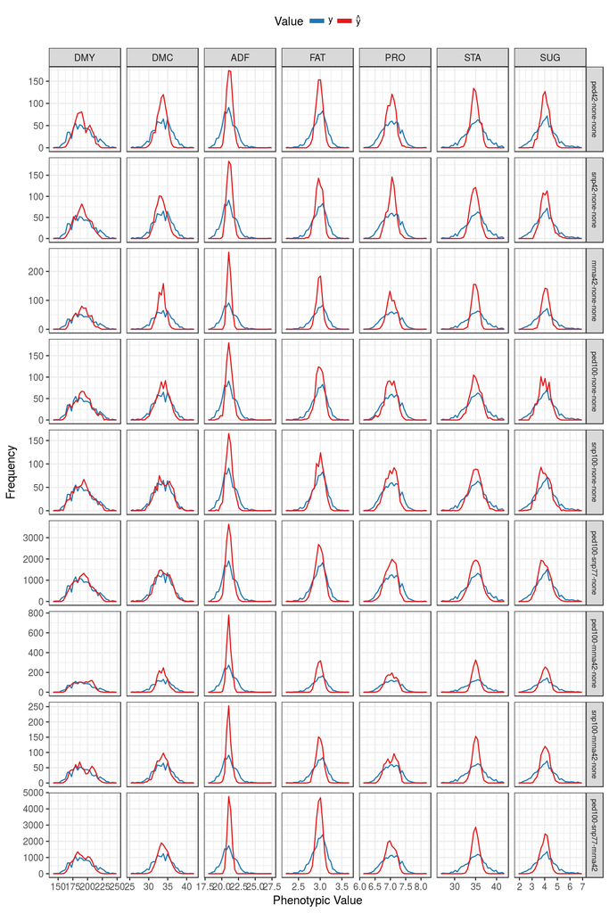

Figure 9.1: Frequency polygon of observed and predicted values for seven agronomic traits (columns) and nine sets of predictors (rows).

## 9.2 Coefficient of variation for predicted values

We are interested in the variation in the predicted values relative to the arithmetic mean of the predicted values, separately for each agronomic trait and each set of predictors:

$$\begin{equation}
\label{eq:CV}
CV = \sqrt{\frac{\sum_{i = 1}^{N} \sigma^{2}_{\hat{y}(i)} / N}{\sum_{i=1}^{N}\hat{y}_{i} / N}},
\end{equation}$$

where $N$ denotes the number of hybrids.

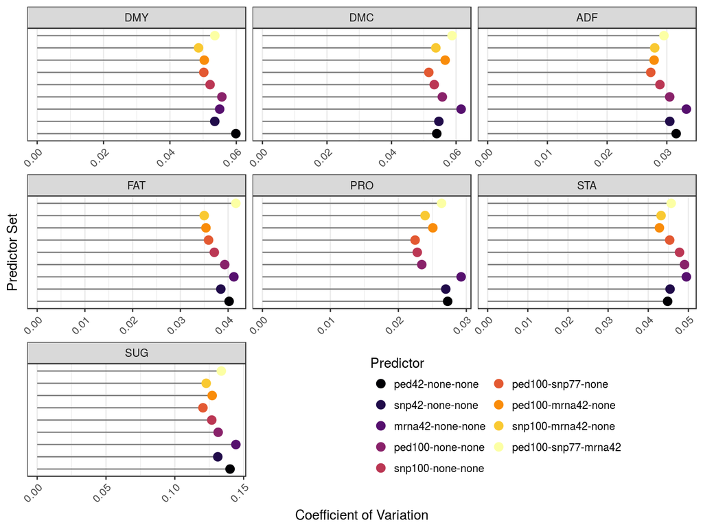

Figure 9.2: Coefficient of variation for seven agronomic traits and nine sets of predictors.

## 9.3 Predictive Abilities

For an introduction to the abbreviations used for the different predictors, and combinations thereof, please refer to chapter 6.

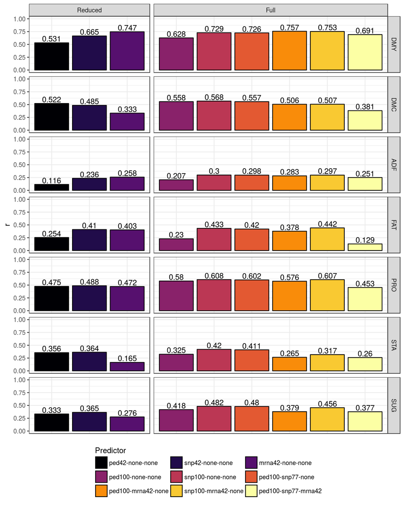

Figure 9.3: Predictive ability for seven agronomic traits (rows) and nine predictor sets (columns). The predictor sets are split into the categories ‘Reduced’ (i.e. 685 hybrids) and ‘Full’ (i.e. 1,521 hybrids). For both categories, predictive abilities are based solely on the set of 685 common hybrids. Predictions including ‘snp77’ are based on 20 runs where each run was assembled by selecting a set of genotypes at random. The resampling procedure took into account the difference in absolute size between sets of Dent and the Flint parent lines. In these instances, the arithmetic mean of predictive abilities across all 20 runs is displayed.

### 9.3.1 Findings

1. Reduced
- For dry matter yield, transcriptomic data clearly perform best.
- Genomic data perform decisively better than pedigree data for DMY, ADF and FAT.
- Relative to pedigree and genomic data, transcripts perform poorly for DMC and STA.
2. Full
- SNP data perform better for all traits compared to pedigree information.
- Predictive abilities for the combination of pedigree, SNP and transcriptomic data “ped100-snp77-mrna42” seem to be the sum of the predictive abilities of the individual predictors weighted by their share of the genotypes. For example
  $$r(\text{ped100-snp77-mrna42}) = r(\text{ped100}) * (1 - 0.77) +
  r(\text{snp77}) * (0.77 - 0.42) + r(\text{mrna42}) * 0.42$$
- The predictive ability of only two predictors is typically higher than a weighted average of the predictive abilities of the constituting individual predictors.
- Predictive abilities for FAT and the predictor combination “ped100-snp77-mrna42” are difficult to explain. **Suggestions???**
3. General
- If a reduced predictor performed better than another predictor in the reduced data set (e.g. ‘mrna42’ vs. ‘snp42’ for DMY), it will boost the performance of the other predictor (here ‘snp100’) in the full set when the two predictors are combined in a single-step approach (here ‘snp100-mrna-42-none’).

#### 9.3.1.1 Predictive abilities for predictor sets with resampling.

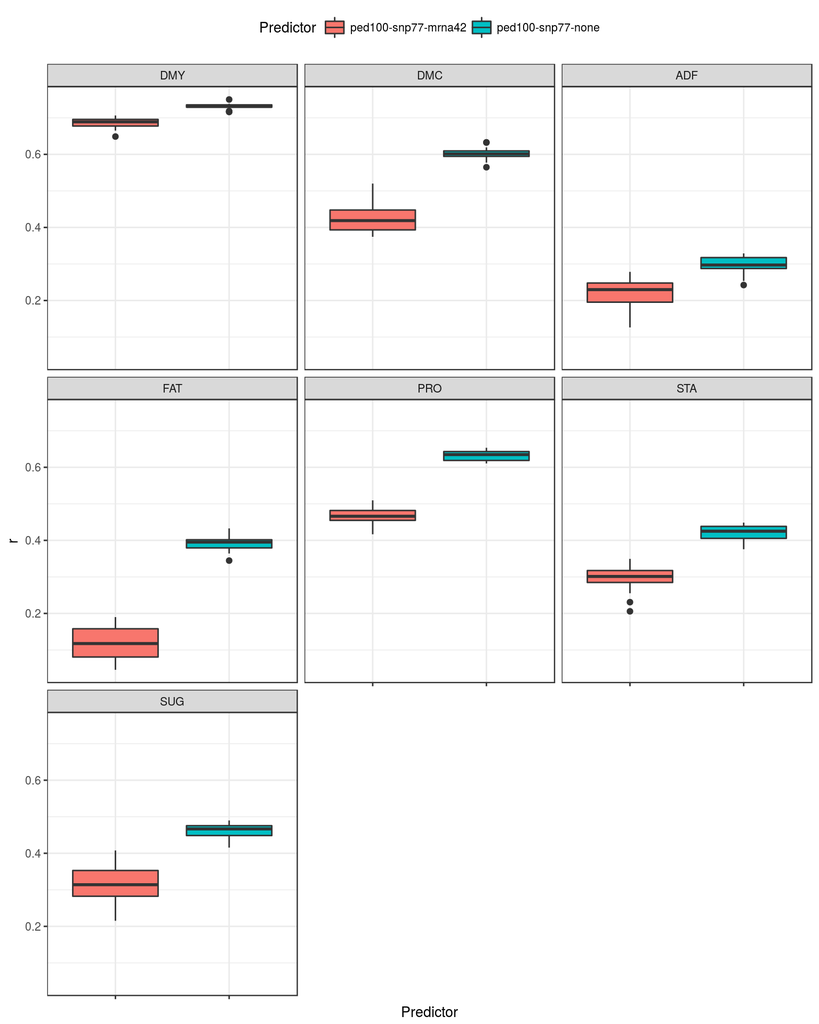

Figure 9.4: Predictive ability for two scenarios and seven agronomic traits where the composition of the set of genomic predictors ‘snp77’ is based on sampling at random for 20 times. Predictive abilities are based solely on the set of 685 common hybrids.

# 10 Outlook

## 10.1 Size of individual predictors

We have not yet investigated the influence of the size (in terms of the number of parental genotypes) of an individual predictor on the predictive ability achieved with a combination of multiple predictors in a single-step prediction settting. Consider the following predictors in single-step prediction, where nothing changes but the coverage of genotypes through genomic data in increments of 10%:

1. ‘ped100-snp90’ or ‘ped100-snp90-mrna42’
2. ‘ped100-snp80’ or ‘ped100-snp80-mrna42’
3. $\dots$ or $\dots$
4. ‘ped100-snp10’ or ‘ped100-snp10-mrna42’

Using such an iterative approach, we might get closer to describing the contribution of individual predictors to the predictive ability in a combined single-step predictor.

One caveat here is that, so far, we have sampled ‘snp77’ at random (except for the adjustment to sampling, in relative terms, equally large fractions from the Dent and the Flint group, respectively). If we run the scenario proposed above, we would have a high computational load. What I am looking for is a way to sample ‘snpXX’ — where XX reprents the fraction of all possible genotypes covered — such that it covers the genetic target space (i.e. the whole set of 142 parental Dent and 103 parental Flint lines) equally well. Bustos-Korts et al. (2016) have described a uniform sampling procedure that we might be able to use for this purpose. To evaluate the soundness of the method described in this publication, we could compare the predictive ability obtained with ‘snp77’ from uniform sampling with the mean (or median) of the predictive ability for ‘snp77’ from repeated random sampling (20 replications, see Figure 9.4).

## 10.2 Algorithm validation

To validate the algorithms from R. L. Fernando, Dekkers, and Garrick (2014) and its extension in 1, we could perhaps have a look at an independent data set, such as the one described by Guo et al. (2016), who used data from the [Yan lab](http://www.maizego.org/Resources.html).

# 11 References

Bustos-Korts, Daniela, Marcos Malosetti, Scott Chapman, Ben Biddulph, and Fred van Eeuwijk. 2016. “Improvement of Predictive Ability by Uniform Coverage of the Target Genetic Space.” *G3* 6 (November): g3.116.035410. doi:10.1534/g3.116.035410.

Fernando, Rohan L, Jack Cm Dekkers, and Dorian J Garrick. 2014. “A class of Bayesian methods to combine large numbers of genotyped and non-genotyped animals for whole-genome analyses.” *Genetics, Selection, Evolution : GSE* 46 (1): 50. doi:10.1186/1297-9686-46-50.

Fernando, Rohan L., Jack CM Dekkers, and Dorian J. Garrick. 2014. “A Class of Bayesian Methods to Combine Large Numbers of Genotyped and Non-Genotyped Animals for Whole-Genome Analyses.” *Genetics Selection Evolution* 46 (1): 50. doi:10.1186/1297-9686-46-50.

Garrick, Dorian J., Jeremy F. Taylor, and Rohan L. Fernando. 2009. “Deregressing Estimated Breeding Values and Weighting Information for Genomic Regression Analyses.” *Genetics Selection Evolution* 41 (1): 55. doi:10.1186/1297-9686-41-55.

Guo, Zhigang, Michael M. Magwire, Christopher J. Basten, Zhanyou Xu, and Daolong Wang. 2016. “Evaluation of the utility of gene expression and metabolic information for genomic prediction in maize.” *Theor. Appl. Genet.* 129 (12). Springer Berlin Heidelberg: 2413–27. doi:10.1007/s00122-016-2780-5.

Kuhn, Max, and Kjell Johnson. 2013. *Applied predictive modling*. 1st ed. Springer.

Legarra, A., I. Aguilar, and I. Misztal. 2009. “A Relationship Matrix Including Full Pedigree and Genomic Information.” *Journal of Dairy Science* 92 (9): 4656–63. doi:10.3168/jds.2009-2061.

[^1]: This is motivated by the fact that the success of hybrid prediction is a strongly convex function of predictive ability.